# R Notebook

```r
library(data.table)
library(dplyr)
library(ggplot2)
library(cowplot)
library(patchwork)
library(rprojroot)
F =is_rstudio_project$make_fix_file()
```

## Introduction

Here, I will demostrate how to generate the QQplots shown in Fig. 2 of the paper. These QQplots are generated from the GWAS of non-heritable phenotypes so any inflation in the test statistic, which shows up as a deviation from the diagonal is because of residual stratification and not because of polygenicity.

### Implementation

The GWAS output gives us the $\chi^2$ statistic of association and the p-value. To generate the QQplots, we need to generate their expected values and the 95% CI under the null distribution.

QQplots can be slighlty noisy so I carried out GWAS on 20 independent simulations of the phenotype and averaged the test statistic across each for plotting. To make this process memory efficient, I `processed’ each GWAS output by:

1. sorting by the p-value,
2. adding a rank to each variant. This will be used to generate the expected p-value and the 95% CI.
3. indicating whether the variant is common or rare.

This allowed me to drop a lot of unncessary information from the GWAS output (chromosome no. SNP ID, position etc.).

Write function to read in the GWAS result and calculate expected statistics.

```r
#function to summarize
fsummarize=function(phenotype="smooth",
                    correction="pcs0"){
  #read the dataframe
  dat = fread(F(paste("gwas/grid/genotypes/tau-9/ss500/train/gwas_results/fixed_effects/noge/genos_gridt9_",
                    phenotype,".",
                    correction,
                    ".all.txt.gz",sep="")))
  colnames(dat) = c("fcat","ID","P","ix")

  dat=dat[,.(fcat,P,ix),]
  #calculate the expected p-value from the rank
  #observed chi-squared statistic from the observed p-values
  dat[,c("exp.p","obs.chi"):=list(
    ix/(max(ix)+1),
    qchisq(P,df=1,lower.tail = FALSE)
    ), by=fcat]

  #calculate expected chi-squared and genomic inflation
  dat[,"exp.chi":=qchisq(exp.p,df=1,lower.tail = FALSE)]
  dat[,"lambda":=obs.chi/exp.chi]
  dat=dat[,chi.percentile:=1-exp.p]

  #calculate 95% CI of the expected p-value
  dat[,lower.ci:=qbeta(0.025,
                       shape1=ix,
                       shape2 = max(ix)-ix),by=fcat]
  dat[,upper.ci:=qbeta(0.975,
                       shape1=ix,
                       shape2 = max(ix)-ix),by=fcat]
  dat = dat[, lapply(.SD,mean),
            by = .(fcat,ix)]

  return(dat)
}
#write function to generate the QQplots.
fplot=function(dat,title="No correction"){

  plt1<-ggplot(data=dat)+
    geom_ribbon(aes(x=-log10(exp.p),
                    ymin=-log10(lower.ci),
                    ymax=-log10(upper.ci),
                    fill=fcat),
                alpha=0.2,
                show.legend = FALSE)+
    geom_line(aes(-log10(exp.p),
                  -log10(P),
                  color=fcat),
              size=0.7,
              alpha=0.5,
              show.legend = FALSE)+
        geom_abline(intercept=0,slope=1,color="black")+
    scale_color_manual(values=c("#ff7f00","#377eb8"))+
    scale_fill_manual(values=c("#ff7f00","#377eb8"))+
    theme_bw()+
    theme(panel.grid=element_blank(),
          axis.text=element_text(size=10),
          plot.title = element_text(hjust=0.5),
          plot.background = element_blank(),
          plot.margin = unit(rep(0.5,4), "pt"))+
    labs(color="Freq.",
         title=title)+
    xlim(c(0,max.log10P))+
    ylim(c(0,max.log10P))

  plt.inset=ggplot()+
    geom_line(data=dat[chi.percentile>0.999,],
              aes(chi.percentile,
                  lambda,
                  color=fcat),
              show.legend = FALSE,
              size=0.5)+
    annotate(geom="text",
             x=0.9993,
             y=0.9*max.lambda,
             label="lambda[p]",parse=TRUE)+
    theme_bw()+
    theme(panel.grid.major.x = element_blank(),
          legend.position="none",
          axis.title=element_blank(),
          panel.grid=element_blank(),
          plot.background = element_blank(),
          axis.text.x = element_text(hjust=0,size=9),
          axis.text.y = element_text(size=9))+
    scale_x_log10(limits=c(0.999,1),
                  breaks=c(0.999,1),
                  labels=c("0.999","1"),
                  position="top")+
    scale_y_continuous(limits=c(0.99, round(max.lambda,2)),
                       breaks=c(1, round(max.lambda,2)),
                       position="left")+
    labs(x="p")+
    scale_color_manual(values=c("#ff7f00","#377eb8"))

  plt.wt.inset<-ggdraw(plt1) +
    draw_plot(plt.inset, x=0.3, y=0.08, height=0.4,width=0.7)

  return(plt.wt.inset)
}
```

Read in the GWAS files for the `smooth’ phenotype for each method of correction, add the expected statistics, and calculate genomic inflation.

```r
dat1=fsummarize("smooth","pcs0")
dat2=fsummarize("smooth","cm")
dat3=fsummarize("smooth","re")
median.lambda=lapply(list(dat1,dat2,dat3),
                     function(x){
                       return(
                         x[chi.percentile>0.49 &
                                    chi.percentile<0.51,
                                  median(lambda),by=fcat])
                     })
names(median.lambda)=c("pcs0","common","rare")
median.lambda=bind_rows(median.lambda,.id="correction")
colnames(median.lambda)[3]="lambda1"
median.lambda
```

| correction | fcat | lambda1 |
| --- | --- | --- |
| pcs0 | common | 1.158366 |
| pcs0 | rare | 1.129383 |
| common | common | 1.023470 |
| common | rare | 1.019286 |
| rare | common | 1.007668 |
| rare | rare | 1.005272 |

Generate the QQplots for the smooth phenotype.

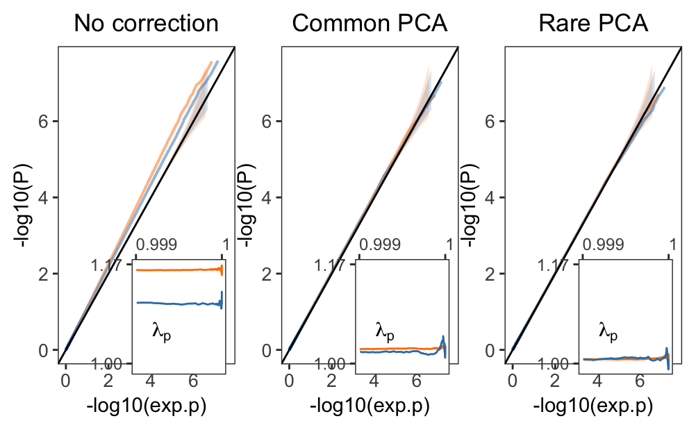

```r
max.lambda=max(sapply(list(dat1,dat2,dat3),
                      function(x){
                        max( x[ which(x$chi.percentile>0.999), "lambda"])
                      }))
max.log10P=max(sapply(list(dat1,dat2,dat3),
                      function(x){
                        max(-log10(x$P))
                      }))
plt1=fplot(dat1,"No correction")
plt2=fplot(dat2,"Common PCA")
plt3=fplot(dat3,"Rare PCA")
plt_combined.sm=plt1+theme(axis.title.x=element_blank())+
  plt2+
  plt3+theme(axis.title.x=element_blank())
plt_combined.sm
```

Plot for the sharp effect.

```r
dat1=fsummarize("sharp","pcs0")
dat2=fsummarize("sharp","cm")
dat3=fsummarize("sharp","re")
median.lambda=lapply(list(dat1,dat2,dat3),
                     function(x){
                       return(
                         x[chi.percentile>0.49 &
                                    chi.percentile<0.51,
                                  median(lambda),by=fcat])
                     })
names(median.lambda)=c("pcs0","common","rare")
median.lambda=bind_rows(median.lambda,.id="correction")
colnames(median.lambda)[3]="lambda1"
median.lambda
```

| correction | fcat | lambda1 |
| --- | --- | --- |
| pcs0 | common | 1.0098105 |
| pcs0 | rare | 0.9906909 |
| common | common | 1.0071084 |
| common | rare | 0.9918326 |
| rare | common | 1.0055924 |
| rare | rare | 0.9921018 |

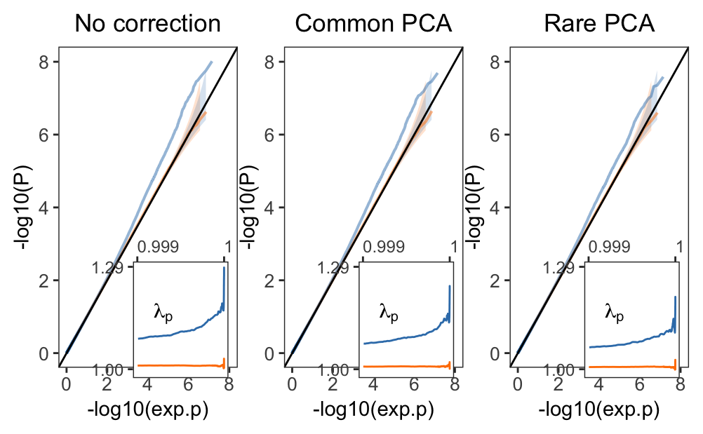

```r
max.lambda=max(sapply(list(dat1,dat2,dat3),
                      function(x){
                        max( x[ which(x$chi.percentile>0.999), "lambda"])
                      }))
max.log10P=max(sapply(list(dat1,dat2,dat3),
                      function(x){
                        max(-log10(x$P))
                      }))
plt1=fplot(dat1,"No correction")
plt2=fplot(dat2,"Common PCA")
plt3=fplot(dat3,"Rare PCA")
plt_combined.shp=plt1+plt2+plt3
plt_combined.shp
```

```r
plt_combined.both=plt_combined.sm/plt_combined.shp

ggsave(F("plots/qqplots/plt_qq_t9_07032020.pdf"),
       plt_combined.both,
       height=12,
       width=14,
       units="cm")
```